# doc_labstrains

Kaitlin A. Schaal

2023-03-08

### 1: visualize the data

```r
data <- read.csv("data_labstrains.csv")
str(data)
```

```
## 'data.frame':    159 obs. of  9 variables:
##  $ replicate  : int  1 1 1 1 1 1 1 1 1 1 ...
##  $ plate      : chr  "WT low" "WT high" "WT high" "Ch1 low" ...
##  $ strain     : chr  "WT" "WT" "WT" "Ch1" ...
##  $ nutrients  : chr  "low" "high" "high" "low" ...
##  $ strain2    : chr  "none" "none" "none" "none" ...
##  $ nutrients2 : chr  "none" "none" "none" "none" ...
##  $ antibiotics: chr  "none" "none" "rif" "none" ...
##  $ dilution   : int  5 5 4 1 1 1 1 1 1 1 ...
##  $ cfus       : int  87 46 0 0 0 2 0 0 0 3 ...
```

```r
# remove the data for csgA, which we don't use because it didn't show cheating under standard conditions, which is what we are specifically interested in
data <- data[which(!(data$strain == "csgA")),]
# remove data for replicate 2 for WT:Ch1 where Ch1 experienced high nutrients, because CFU plates were contaminated
data <- data[which(!(data$replicate == 2 & data$strain == "Ch1" & data$nutrients == "high")),]

data$plate <- as.factor(data$plate)
data$strain <- as.factor(data$strain)
data$nutrients <- as.factor(data$nutrients)
data$strain2 <- as.factor(data$strain2)
data$nutrients2 <- as.factor(data$nutrients2)
data$antibiotics <- as.factor(data$antibiotics)

# for counts of zero CFUs, calculate the maximum undetectable number of CFUs.
for (i in 1:nrow(data)) {
  if (data$cfus[i] == 0) data$cfus[i] <- 0.9
}

# calculate the total number of spores
data <- mutate(data, numspores = cfus * 10^dilution)
data <- mutate(data, logspores = log10(numspores + 1))
str(data)
```

```
## 'data.frame':    105 obs. of  11 variables:
##  $ replicate  : int  1 1 1 1 1 1 1 1 1 1 ...
##  $ plate      : Factor w/ 14 levels "Ch1 high","Ch1 low",..: 10 5 5 2 2 1 1 4 4 3 ...
##  $ strain     : Factor w/ 3 levels "Ch1","Ch2","WT": 3 3 3 1 1 1 1 2 2 2 ...
##  $ nutrients  : Factor w/ 2 levels "high","low": 2 1 1 2 2 1 1 2 2 1 ...
##  $ strain2    : Factor w/ 2 levels "none","WT": 1 1 1 1 1 1 1 1 1 1 ...
##  $ nutrients2 : Factor w/ 3 levels "high","low","none": 3 3 3 3 3 3 3 3 3 3 ...
##  $ antibiotics: Factor w/ 2 levels "none","rif": 1 1 2 1 2 1 2 1 2 1 ...
##  $ dilution   : int  5 5 4 1 1 1 1 1 1 1 ...
##  $ cfus       : num  87 46 0.9 0.9 0.9 2 0.9 0.9 0.9 3 ...
##  $ numspores  : num  8700000 4600000 9000 9 9 20 9 9 9 30 ...
##  $ logspores  : num  6.94 6.66 3.95 1 1 ...
```

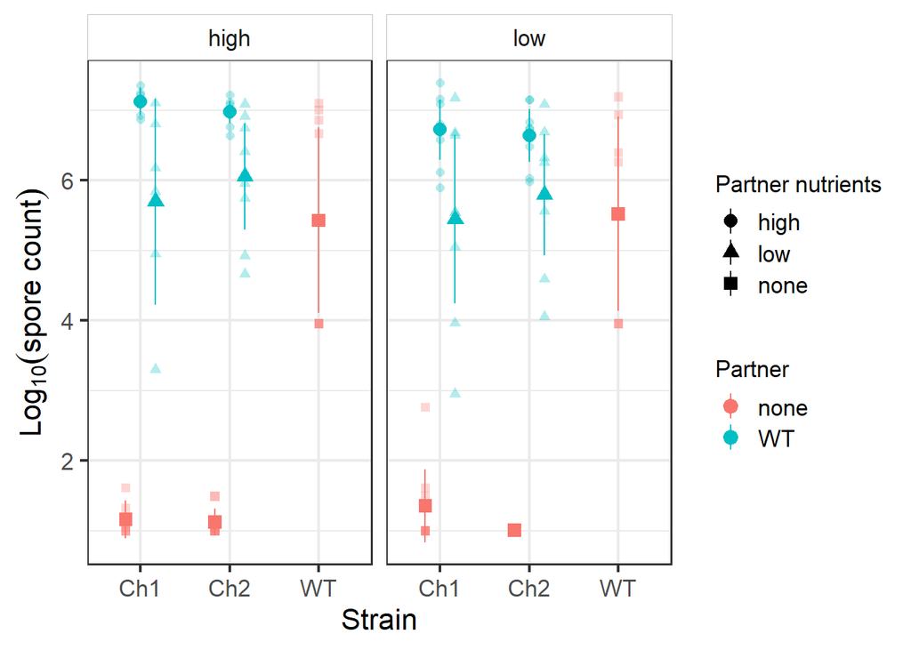

```r
pdata <- ggplot(data, aes(x = strain, y = logspores, color = strain2, shape = nutrients2)) +
  geom_point(size = 2, alpha = 0.3, show.legend = FALSE, position = position_dodge(width = 0.5)) +
  stat_summary(fun.data = "mean_cl_normal", size = 0.7, aes(y = logspores), position = position_dodge(width = 0.5)) +
  facet_wrap(~nutrients, dir = "v", ncol = 2) +
  labs(y = expression(Log[10]("spore count")), x = "Strain", color = "Partner", shape = "Partner nutrients") +
  customPlotTheme
pdata
```

It looks like for Ch1 and Ch2, spoulation is lower when partner nutrients are low, regardless of own nutrient level.

#### 1.1: checking marker effects

Clonal cultures of each strain were germinated in media with or without antibiotic as a control for the effect of the antibiotic on viable spore counts. As expected, WT did not produce spores in the presence of the antibiotic, as can be seen by the 0 counts in the initial data table. We look at the effect of antibiotics on the CFUs counts obtained from the cheater strains.

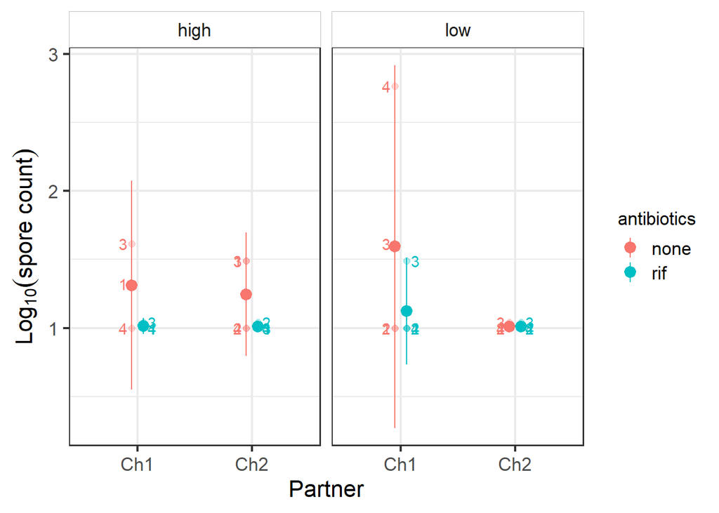

```r
# select the data for the cheaters in pure culture and remove levels from the parent data set that are no longer present
dataTest <- data[which(data$strain2 == "none" & data$strain != "WT"),]
dataTest <- droplevels(dataTest)

pmarker <- ggplot(dataTest, aes(x = strain, y = logspores, color = antibiotics, label = replicate)) +
  geom_point(size = 2, alpha = 0.3, show.legend = FALSE, position = position_dodge(width = 0.2)) +
  stat_summary(fun.data = "mean_cl_normal", size = 0.7, aes(y = logspores), position = position_dodge(width = 0.2)) +
  facet_wrap(~nutrients, dir = "v", ncol = 2) +
  geom_text(position = position_dodge(width = 0.5), show.legend = FALSE) +
  labs(y = expression(Log[10]("spore count")), x = "Partner") +
  customPlotTheme
pmarker
```

For each strain under each condition, we check for evidence of no effect by looking at the confidence intervals for the difference in means.

```r
# initialize a data frame to store the resulting confidence intervals for each test
cis <- data.frame(strains = levels(dataTest$plate), mean = 1, lower = 1, upper = 1)

# for each strain under low or high nutrients, test the difference in means with vs without antibiotic, paired by replicate
for (i in 1:length(levels(dataTest$plate))) {
  x = dataTest[which(dataTest$plate == levels(dataTest$plate)[i] & dataTest$antibiotics == "none"), "logspores"]
  y = dataTest[which(dataTest$plate == levels(dataTest$plate)[i] & dataTest$antibiotics == "rif"), "logspores"]
  result <- MeanDiffCI(x, y, method = "classic", conf.level = 0.95, sides = "two.sided", paired = TRUE)
  cis[i,2] <- result[1]
  cis[i,3] <- result[2]
  cis[i,4] <- result[3]
}
cis
```

```
##    strains      mean      lower     upper
## 1 Ch1 high 0.2978702 -0.4137676 1.0095079
## 2  Ch1 low 0.4713996 -0.9030189 1.8458181
## 3 Ch2 high 0.2353327 -0.2358594 0.7065247
## 4  Ch2 low 0.0000000        NaN       NaN
```

There is no difference between with or without antibiotic for Ch2 grown at low nutrient because it doesn’t produce spores. The most difference the antibiotic treatment might produce is a 10- to 100-fold decrease in CFU count in Ch1. However, keep in mind that we are measuring at the very low end of the range of spore production values. Overall, we conclude that there is reasonable evidence application of antibiotic may not significantly impact the number of CFUs counted.

### 2: pure culture spoulation in different nutrient conditions

```r
dataPC <- data[which(data$strain2 == "none"),]
dataPC <- dataPC[which(!(dataPC$strain == "WT" & dataPC$antibiotics == "rif")),]
dataPC <- dataPC[which(!(dataPC$strain != "WT" & dataPC$antibiotics == "none")),]
```

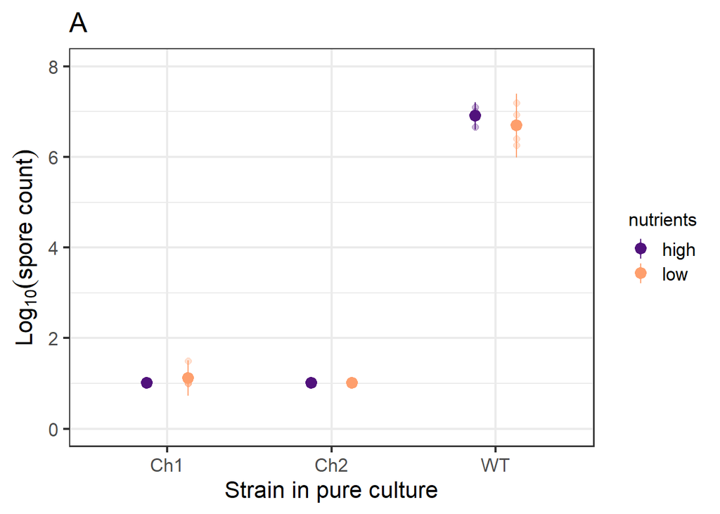

```r
pPC <- ggplot(dataPC, aes(x = strain, y = logspores, color = nutrients)) +
  geom_point(size = 2, alpha = 0.3, show.legend = FALSE, position = position_dodge(width = 0.5)) +
  stat_summary(fun.data = "mean_cl_normal", size = 0.7, aes(y = logspores), position = position_dodge(width = 0.5)) +
  coord_cartesian(ylim = c(0,8)) +
  labs(y = expression(Log[10]("spore count")), x = "Strain in pure culture", title = "A") +
  customPlotTheme +
  scale_color_viridis_d(option = "magma", begin = 0.25, end = 0.8, direction = 1)
pPC
```

#### 2.1: statistics

We are interested in whether prior nutrient conditions affect sporulation of the WT strain or the cheater strains when grown in monoculture. We run an ANOVA for strain ID x nutrient level affecting log(spore estimate).

```r
fit <- aov(logspores ~ strain * nutrients, data = dataPC)
summary(fit)
```

```
##                  Df Sum Sq Mean Sq F value Pr(>F)
## strain            2 173.14   86.57 1673.17 <2e-16 ***
## nutrients         1   0.01    0.01    0.18  0.677
## strain:nutrients  2   0.10    0.05    0.95  0.406
## Residuals        17   0.88    0.05
## ---
## Signif. codes:  0 '***' 0.001 '**' 0.01 '*' 0.05 '.' 0.1 ' ' 1
```

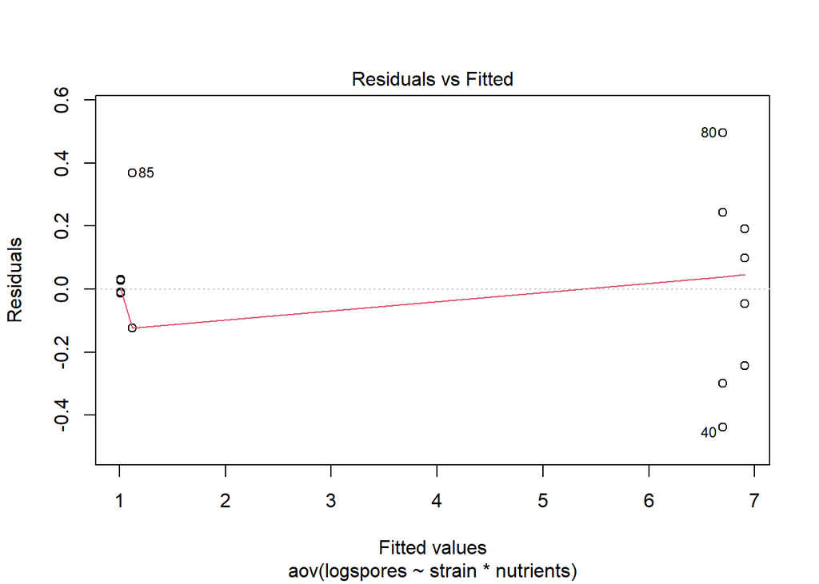

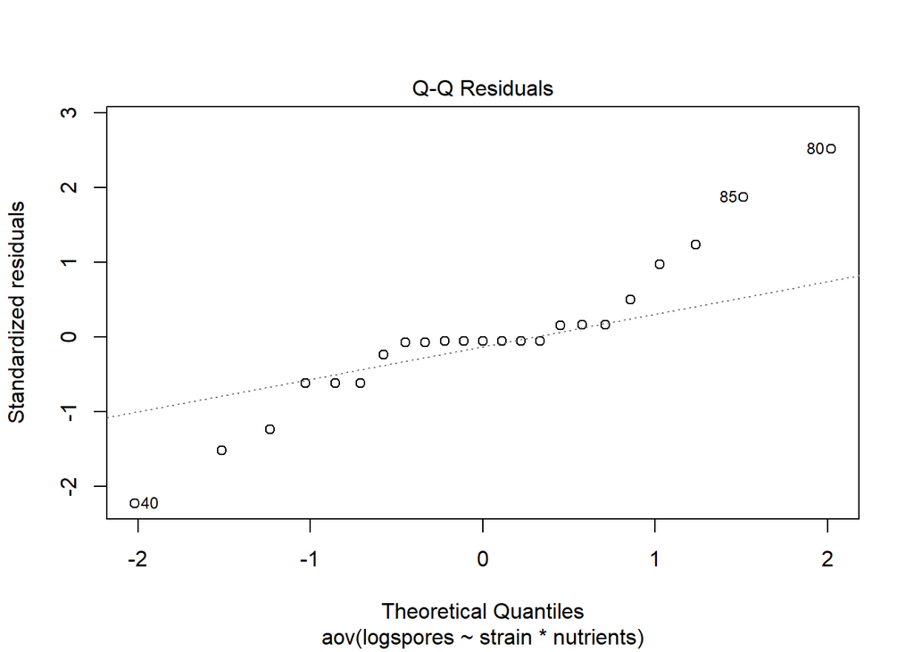

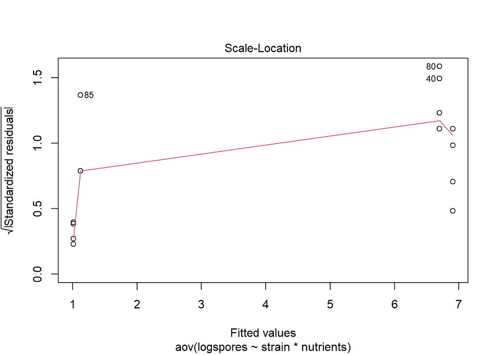

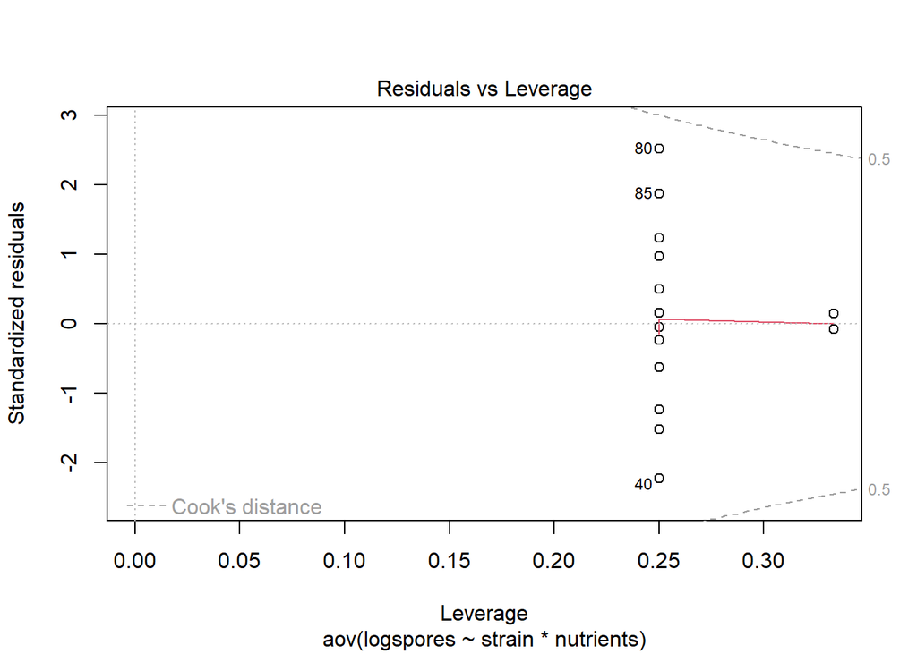

```r
plot(fit)
```

```r
# test whether there is a difference in estimated spore production between high and low nutrients for each strain

# initialize a data frame to store the resulting p-value, mean, and 95% CI for each test
cis <- data.frame(strains = levels(dataPC$strain), pval = 1, tstat = 1, df = 1, stdev = 1, meanHigh = 1, meanLow = 1, CIlower = 1, CIupper = 1)

# initialize a vector to store the p-values from each test so that they can be corrected for multiple testing
pvalues <- c()

# run the iterated tests
for (i in 1:length(levels(dataPC$strain))) {
  n = 4 # the number of samples
  dataTest <- subset(dataPC, strain == levels(dataPC$strain)[i])
  res <- t.test(dataTest$logspores ~ dataTest$nutrients, alternative = "two.sided", mu = 0)
  pvalues <- c(pvalues, res$p.value)
  cis[i,3] <- res$statistic
  cis[i,4] <- res$parameter
  cis[i,5] <- res$stderr * n^2
  cis[i,6] <- as.numeric(res$estimate[1])
  cis[i,7] <- as.numeric(res$estimate[2])
  cis[i,8] <- as.numeric(res$conf.int[1])
  cis[i,9] <- as.numeric(res$conf.int[2])
}

# do the multiple testing correction
pCorr <- round(p.adjust(pvalues, method = "BH"), 4)

# enter the corrected p-values into the data frame
for (i in 1:nrow(cis)) {
  cis[i,2] <- pCorr[i]
}
cis
```

```
##   strains   pval      tstat       df     stdev meanHigh  meanLow     CIlower
## 1     Ch1 0.6618 -0.8821319 3.075439 1.9778060 1.013798 1.122840 -0.49703108
## 2     Ch2 1.0000  0.0000000 6.000000 0.2341524 1.010348 1.010348 -0.03580939
## 3      WT 0.6618  0.8680088 4.061748 3.8500304 6.905932 6.697066 -0.45523459
##      CIupper
## 1 0.27894535
## 2 0.03580939
## 3 0.87296714
```

We find no convincing evidence for a difference in pure-culture sporulation based on prior nutrient conditions in any of the strains.

```r
# power.t.test(n = 4, delta = 1, sd = 14.52, sig.level = 0.05, type = "two.sample", alternative = "two.sided")


# The t-test does not have enough power to detect 1 log of difference between nutrient treatments for csgA. From the graph, we do see a large increase in variance under the low nutrient condition, which is something we can analyze using an F-test.


# var.test(logspores ~ nutrients, data = dataPC[which(dataPC$strain == "csgA"),], alternative = "two.sided")


# There is significantly more variation in csgA sporulation after the low nutrient treatment.
```

### 3: analyze cheating

As in previous literature, we assess cheating by defective strains by computing the relative fitness measure Wij. If a strain is defective in pure culture (producing significantly fewer spores than it’s closest WT relative) but has a higher relative fitness (or positive Wij) in mixture with that relative, then we say that it cheats.

Wij = log10(number spores of cheater in mixture/number initial cells of cheater in mixture) - log10(number spores of partner in mixture/number initial cells of partner in mixture).

This is equivalent to

Wij = log10(initial mixing ratio of partner:cheater * number spores of cheater in mixture/number spores of partner in mixture).

```r
dataC <- data[which(data$strain2 != "none" & data$antibiotics == "rif"),] # take the cheaters in mixture
dataT <- data[which(data$strain2 != "none" & data$antibiotics == "none"),] # take the mixture totals

dataC <- mutate(dataC, wij = 17)
for (i in 1:nrow(dataC)) {
  dataC$wij[i] <- log10(9 * dataC$numspores[i]/(dataT$numspores[i] - dataC$numspores[i])) # 9:1 being the mixing ratio of partner:cheater, and we get the number of partner spores by subtracting the cheater spores from the total
}
```

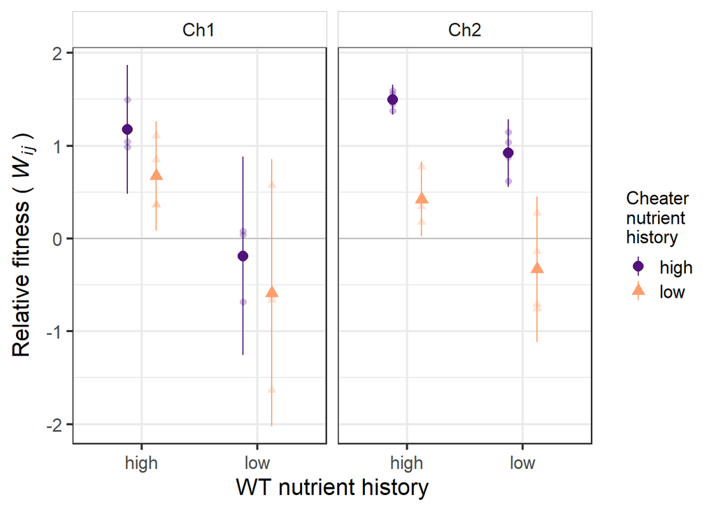

```r
pC <- ggplot(dataC, aes(x = nutrients2, y = wij, color = nutrients, shape = nutrients, label = replicate)) +
  geom_abline(slope = 0, intercept = 0, color = "grey") +
  geom_point(size = 2, alpha = 0.3, show.legend = FALSE, position = position_dodge(width = 0.5)) +
  stat_summary(fun.data = "mean_cl_normal", size = 0.7, aes(y = wij), position = position_dodge(width = 0.5)) +
  facet_wrap(~strain, dir = "h", ncol = 3) +
  labs(y = "Relative fitness ("~italic(W[ij])~")", x = "WT nutrient history", color = "Cheater\nnutrient\nhistory", shape = "Cheater\nnutrient\nhistory") +
  #geom_text(nudge_x = 0.3) +
  customPlotTheme +
  scale_color_viridis_d(option = "magma", begin = 0.25, end = 0.8, direction = 1)
pC
```

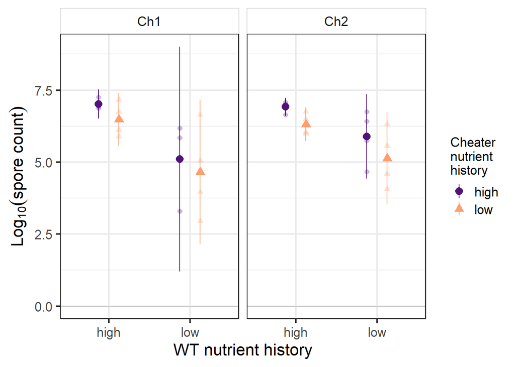

```r
pCspores <- ggplot(dataC, aes(x = nutrients2, y = logspores, color = nutrients, shape = nutrients)) +
  geom_abline(slope = 0, intercept = 0, color = "grey") +
  geom_point(size = 2, alpha = 0.3, show.legend = FALSE, position = position_dodge(width = 0.5)) +
  stat_summary(fun.data = "mean_cl_normal", size = 0.7, aes(y = logspores), position = position_dodge(width = 0.5)) +
  facet_wrap(~strain, dir = "h", ncol = 3) +
  labs(y = expression(Log[10]("spore count")), x = "WT nutrient history", color = "Cheater\nnutrient\nhistory", shape = "Cheater\nnutrient\nhistory") +
  customPlotTheme +
  coord_cartesian(ylim = c(0,NA)) +
  scale_color_viridis_d(option = "magma", begin = 0.25, end = 0.8, direction = 1)
pCspores
```

#### 3.1: statistics

We first want to test whether Ch1 and Ch2 cheat under standard (high/high) conditions. We have an a priori expectation of cheating in these cases, based on existing literature, so we use single t-tests.

```r
c("Ch1")
```

```
## [1] "Ch1"
```

```r
t.test(dataC[which(dataC$strain == "Ch1" & dataC$nutrients == "high" & dataC$nutrients2 == "high"), "wij"], alternative = "greater", mu = 0)
```

```
##
##  One Sample t-test
##
## data:  dataC[which(dataC$strain == "Ch1" & dataC$nutrients == "high" & dataC$nutrients2 == "high"), "wij"]
## t = 7.2838, df = 2, p-value = 0.009166
## alternative hypothesis: true mean is greater than 0
## 95 percent confidence interval:
##  0.704571      Inf
## sample estimates:
## mean of x
##  1.176022
```

```r
c("Ch2")
```

```
## [1] "Ch2"
```

```r
t.test(dataC[which(dataC$strain == "Ch2" & dataC$nutrients == "high" & dataC$nutrients2 == "high"), "wij"], alternative = "greater", mu = 0)
```

```
##
##  One Sample t-test
##
## data:  dataC[which(dataC$strain == "Ch2" & dataC$nutrients == "high" & dataC$nutrients2 == "high"), "wij"]
## t = 29.748, df = 3, p-value = 4.172e-05
## alternative hypothesis: true mean is greater than 0
## 95 percent confidence interval:
##  1.376505      Inf
## sample estimates:
## mean of x
##  1.494757
```

We now test for cheating across the remaining conditions.

```r
dataT <- dataC[which(!(dataC$strain == "Ch1" & dataC$nutrients == "high" & dataC$nutrients2 == "high")),]
dataT <- dataT[which(!(dataT$strain == "Ch2" & dataT$nutrients == "high" & dataT$nutrients2 == "high")),]
dataT <- droplevels(dataT)

# initialize a data frame to store the resulting p-value, mean, and 95% CI for each test
ttests <- data.frame(strains = levels(dataT$plate), pval = 1, tstat = 1, df = 1, stdev = 1, mean = 1, CIlower = 1, CIupper = 1)

# initialize a vector to store the p-values from each test so that they can be corrected for multiple testing
pvalues <- c()

# run the iterated tests
for (i in 1:length(levels(dataT$plate))) {
  n = 4 # the number of samples
  dataTest <- subset(dataT, plate == levels(dataT$plate)[i])
  res <- t.test(dataTest$wij, alternative = "greater", mu = 0)
  pvalues <- c(pvalues, res$p.value)
  ttests[i,3] <- res$statistic
  ttests[i,4] <- res$parameter
  ttests[i,5] <- res$stderr * n^2
  ttests[i,6] <- as.numeric(res$estimate[1])
  ttests[i,7] <- as.numeric(res$conf.int[1])
  ttests[i,8] <- as.numeric(res$conf.int[2])
}

# do the multiple testing correction
pCorr <- round(p.adjust(pvalues, method = "BH"), 4)

# enter the corrected p-values into the data frame
for (i in 1:nrow(ttests)) {
  ttests[i,2] <- pCorr[i]
}
ttests
```

```
##           strains   pval      tstat df    stdev       mean    CIlower CIupper
## 1 WT high:Ch1 low 0.0435  3.6451271  3 2.953333  0.6728297  0.2384380     Inf
## 2 WT high:Ch2 low 0.0435  3.3658986  3 2.013436  0.4235638  0.1274172     Inf
## 3 WT low:Ch1 high 0.8643 -0.7540031  2 3.978472 -0.1874863 -0.9135538     Inf
## 4  WT low:Ch1 low 0.8643 -1.2952858  3 7.226571 -0.5850297 -1.6479515     Inf
## 5 WT low:Ch2 high 0.0120  8.0498469  3 1.829832  0.9206169  0.6514756     Inf
## 6  WT low:Ch2 low 0.8643 -1.3442493  3 3.933239 -0.3304534 -0.9089747     Inf
```

We want to know how Wij may differ across nutrient conditions (of cheater and WT) and cheaters. We run an ANOVA for wij ~ strain * nutrients (cheater) * nutrients2 (WT)

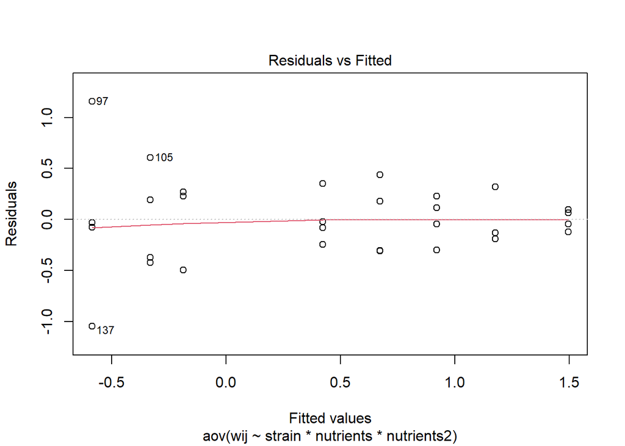

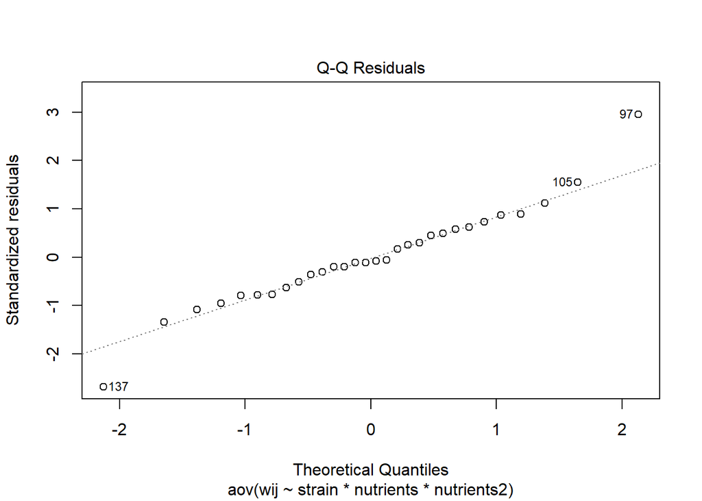

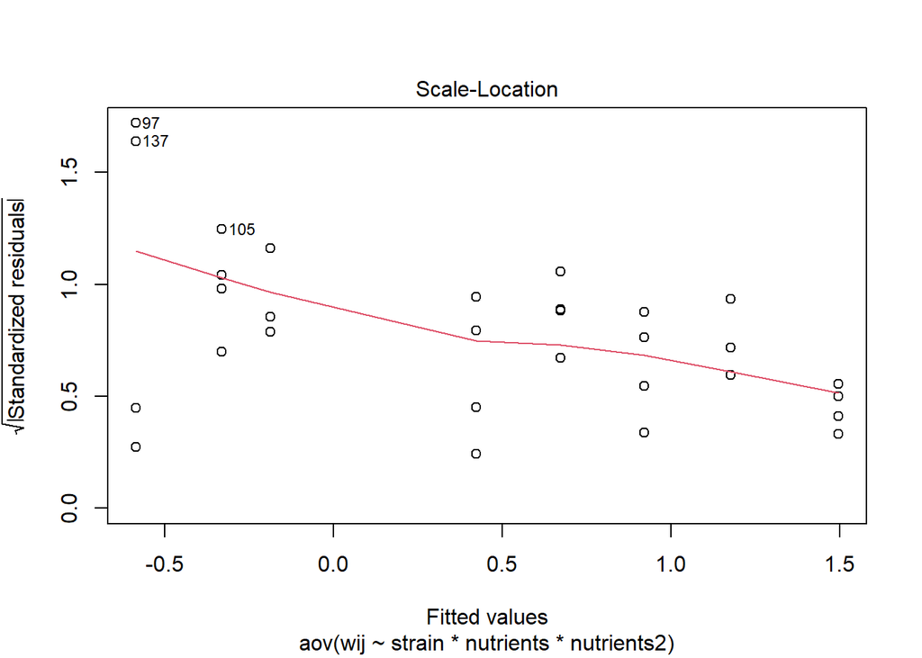

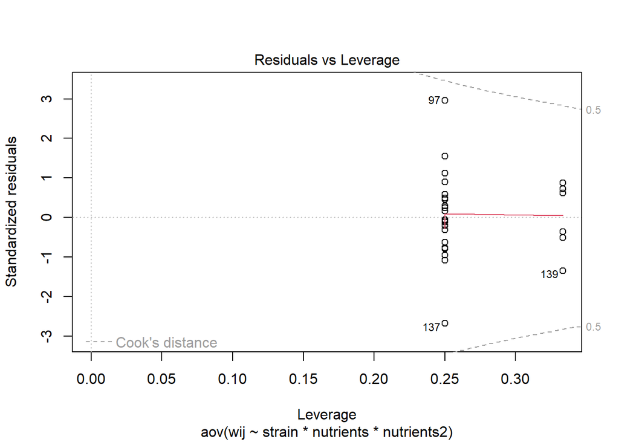

```r
fit <- aov(wij ~ strain * nutrients * nutrients2, data = dataC)
plot(fit)
```

```r
summary(fit)
```

```
##                             Df Sum Sq Mean Sq F value   Pr(>F)
## strain                       1  1.137   1.137   5.575   0.0275 *
## nutrients                    1  5.156   5.156  25.281 4.92e-05 ***
## nutrients2                   1  6.945   6.945  34.056 7.16e-06 ***
## strain:nutrients             1  0.933   0.933   4.573   0.0438 *
## strain:nutrients2            1  0.762   0.762   3.738   0.0662 .
## nutrients:nutrients2         1  0.004   0.004   0.021   0.8859
## strain:nutrients:nutrients2  1  0.038   0.038   0.185   0.6717
## Residuals                   22  4.487   0.204
## ---
## Signif. codes:  0 '***' 0.001 '**' 0.01 '*' 0.05 '.' 0.1 ' ' 1
```

The qqplot looks reasonably normal, so we proceed under the assumption of normality. There is a suggestion that interactions with strain may be significant, so we run individual models for each strain.

##### 3.1.1: Ch1

```r
fit <- aov(wij ~ nutrients * nutrients2, data = dataC[which(dataC$strain == "Ch1"),])
summary(fit)
```

```
##                      Df Sum Sq Mean Sq F value  Pr(>F)
## nutrients             1  0.695   0.695   2.055 0.18223
## nutrients2            1  5.944   5.944  17.563 0.00186 **
## nutrients:nutrients2  1  0.010   0.010   0.028 0.86983
## Residuals            10  3.384   0.338
## ---
## Signif. codes:  0 '***' 0.001 '**' 0.01 '*' 0.05 '.' 0.1 ' ' 1
```

```r
TukeyHSD(fit)
```

```
##   Tukey multiple comparisons of means
##     95% family-wise confidence level
##
## Fit: aov(formula = wij ~ nutrients * nutrients2, data = dataC[which(dataC$strain == "Ch1"), ])
##
## $nutrients
##                diff       lwr       upr     p adj
## low-high -0.4503679 -1.150394 0.2496578 0.1822339
##
## $nutrients2
##               diff       lwr        upr     p adj
## low-high -1.303138 -1.995983 -0.6102918 0.0018556
##
## $`nutrients:nutrients2`
##                          diff       lwr           upr     p adj
## low:high-high:high -0.5031924 -1.862497  0.8561118336 0.6790905
## high:low-high:high -1.3635084 -2.816666  0.0896489745 0.0674365
## low:low-high:high  -1.7610518 -3.120356 -0.4017475741 0.0119615
## high:low-low:high  -0.8603160 -2.219620  0.4989882373 0.2735373
## low:low-low:high   -1.2578594 -2.516331  0.0006117532 0.0501183
## low:low-high:low   -0.3975434 -1.756848  0.9617607784 0.8078343
```

Here the interaction between nutrients of the cheater and of the WT is not significant. Only that of the WT is significant (p = 0.00186), indicating that Wij depends only on the nutrient condition of the WT.

##### 3.1.2: Ch2

```r
fit <- aov(wij ~ nutrients * nutrients2, data = dataC[which(dataC$strain == "Ch2"),])
summary(fit)
```

```
##                      Df Sum Sq Mean Sq F value   Pr(>F)
## nutrients             1  5.393   5.393  58.701 5.84e-06 ***
## nutrients2            1  1.764   1.764  19.201 0.000893 ***
## nutrients:nutrients2  1  0.032   0.032   0.352 0.563896
## Residuals            12  1.102   0.092
## ---
## Signif. codes:  0 '***' 0.001 '**' 0.01 '*' 0.05 '.' 0.1 ' ' 1
```

```r
TukeyHSD(fit)
```

```
##   Tukey multiple comparisons of means
##     95% family-wise confidence level
##
## Fit: aov(formula = wij ~ nutrients * nutrients2, data = dataC[which(dataC$strain == "Ch2"), ])
##
## $nutrients
##               diff       lwr        upr   p adj
## low-high -1.161132 -1.491333 -0.8309303 5.8e-06
##
## $nutrients2
##                diff        lwr        upr     p adj
## low-high -0.6640786 -0.9942799 -0.3338772 0.0008933
##
## $`nutrients:nutrients2`
##                          diff        lwr         upr     p adj
## low:high-high:high -1.0711931 -1.7075044 -0.43488176 0.0015247
## high:low-high:high -0.5741400 -1.2104512  0.06217134 0.0820283
## low:low-high:high  -1.8252102 -2.4615215 -1.18889893 0.0000103
## high:low-low:high   0.4970531 -0.1392582  1.13336440 0.1479753
## low:low-low:high   -0.7540172 -1.3903285 -0.11770587 0.0191767
## low:low-high:low   -1.2510703 -1.8873816 -0.61475898 0.0004019
```

Here the interaction between nutrients of the cheater and of the WT is not significant. Only nutrient conditions in isolation are significant (pcheater = 0.000005, pWT = 0.000893), indicating that the cheater’s nutrient condition matters, but the relative reaction of the cheater to its own nutrient condition is the same regardless of the nutrient condition of the WT.

### Output figures

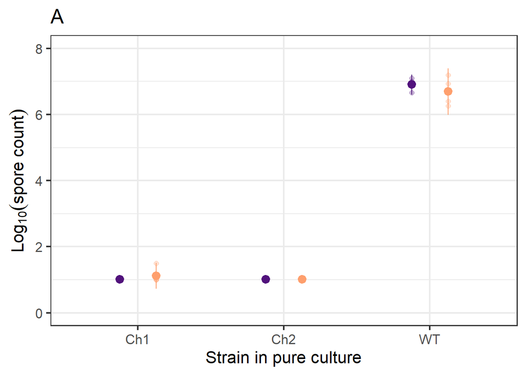

```r
# we alter the graph to fit into the combined figure
pPC <- ggplot(dataPC, aes(x = strain, y = logspores, color = nutrients)) +
  geom_point(size = 2, alpha = 0.3, show.legend = FALSE, position = position_dodge(width = 0.5)) +
  stat_summary(fun.data = "mean_cl_normal", size = 0.7, aes(y = logspores), position = position_dodge(width = 0.5), show.legend = FALSE) +
  coord_cartesian(ylim = c(0,8)) +
  labs(y = expression(Log[10]("spore count")), x = "Strain in pure culture", title = "A") +
  customPlotTheme +
  scale_color_viridis_d(option = "magma", begin = 0.25, end = 0.8, direction = 1)
pPC
```